# Problem 2

```r
library(quantmod)
```

# Problem 2 - Chepurny

## 1.

```r
set.seed(17)
normal <- rnorm(100, mean=10, sd=3)
```

### Histogram vs Density plot

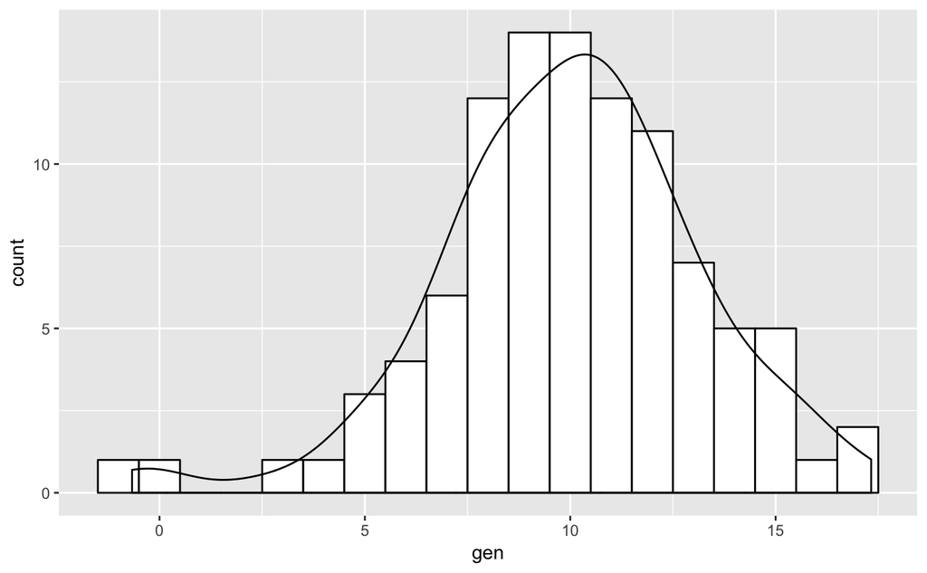

```r
data <- data.frame(gen=normal)
ggplot(data, aes(x=gen)) +
  geom_histogram(binwidth=1, colour="black", fill="white") +
  geom_density(aes(y=..count..))
```

### T5 distribution vs density plot

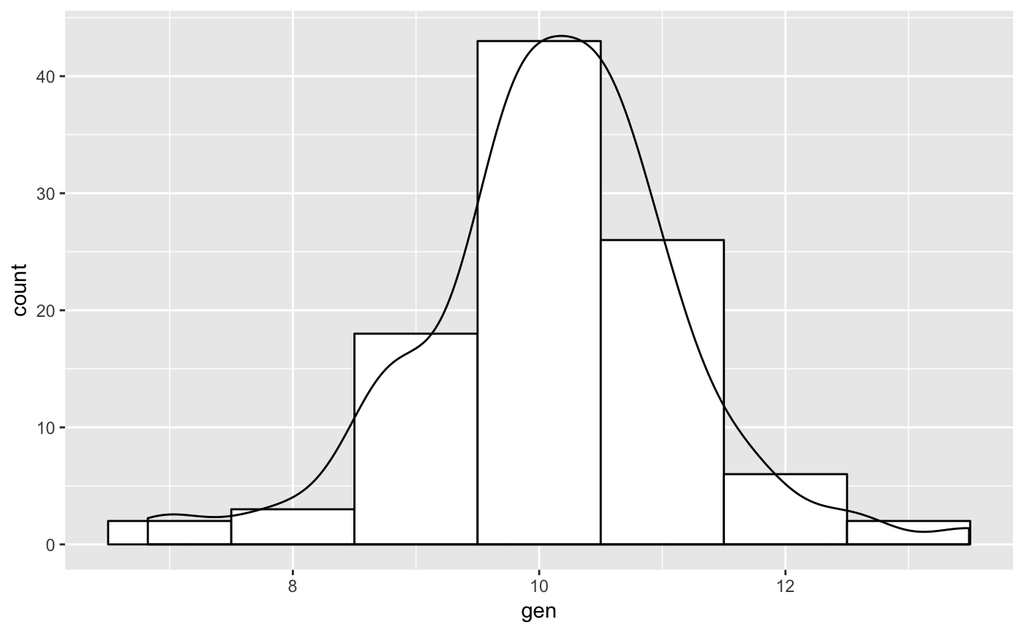

```r
t_dist <- data.frame(gen=rt(100, 5)) %>% mutate(gen=10 + gen * (3/5)^(1/3))
ggplot(t_dist, aes(x=gen)) +
  geom_histogram(binwidth=1, colour="black", fill="white") +
  geom_density(aes(y=..count..))
```

### T Density plot (green) vs N(10, 9) density plot

As we can see, N distribution has higher range of the values and lower density around mean value, although mean values of both distributions are close. Modifying the T distribution (scaling along y axis and shifting along x axis) helped to adjust T distribution mean closer to mean of N distribution. Applying modifications to the distributions can help us to vary mean, density and other measures.

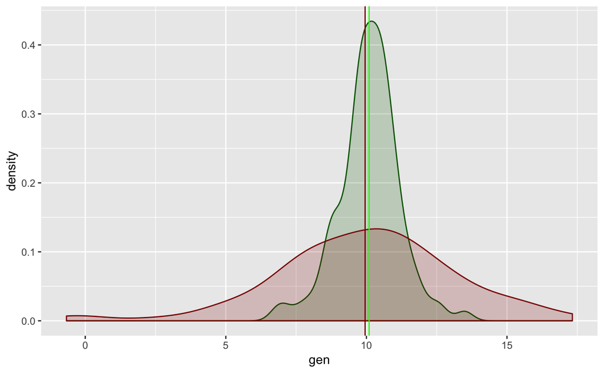

```r
ggplot() +
  geom_density(data=t_dist, aes(x=gen), color='darkgreen', fill='darkgreen', alpha=0.2) +
  geom_density(data=data, aes(x=gen), color='darkred', fill='darkred', alpha=0.2) +
  geom_vline(xintercept = mean(t_dist$gen), color='green') +
  geom_vline(xintercept = mean(data$gen), color='darkred')
```

## 2.

[figure not shown]

[figure not shown]

[figure not shown]

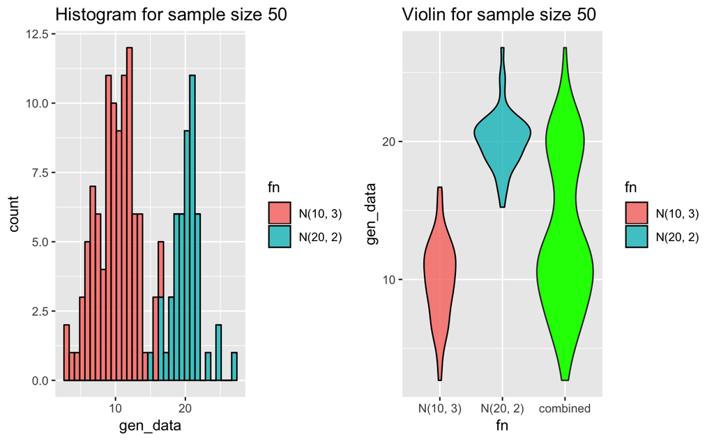

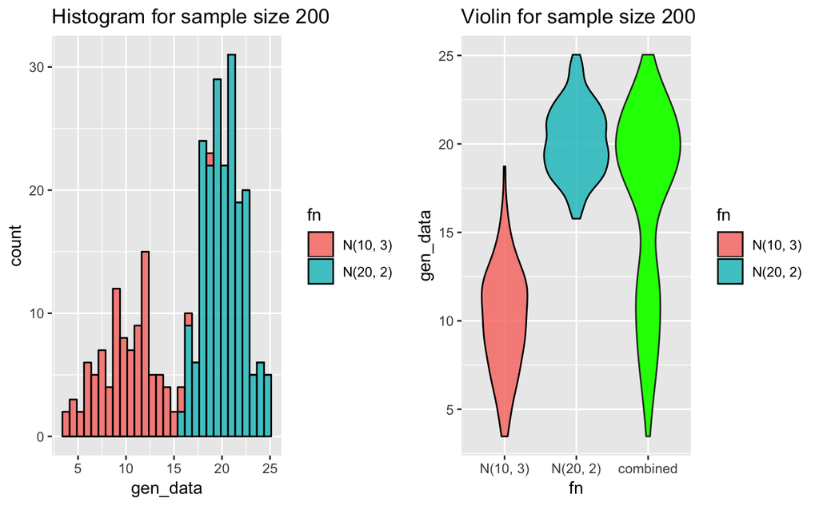

```r
#Initial normal dist
build_plots_for_m <- function(m) {
  n1 <- data.frame(gen_data = rnorm(100, mean=10, sd=3), fn='N(10, 3)')
  mix <- data.frame(gen_data = rnorm(m, mean=20, sd=2), fn='N(20, 2)')

  combined <- rbind(n1, mix)

  hist = ggplot(data=combined, aes(x=gen_data, fill=fn)) +
    ggtitle(paste("Histogram for sample size", m)) +
    geom_histogram(binwidth = 0.75, color='black', alpha=0.8)

  violin = ggplot(data=combined, aes(x=fn,y=gen_data, fill=fn)) +
    ggtitle(paste("Violin for sample size", m)) +
    geom_violin(color='black', alpha=0.8) +
    geom_violin(aes(x='combined', y=combined$gen_data), fill='green')

  return(list(hist=hist, violin=violin))
}
for (m in c(10, 50, 100, 150, 200)) {
  plts = build_plots_for_m(m)
  grid.arrange(plts$hist, plts$violin, nrow=1)
}
```

#### Interactive plot link: https://chepurny.shinyapps.io/prob2/

### 3.

Variance of N(0, 1) is equal to 1 because parameters of N distribution is mean(0) and variance(1)

We need to proove that $U^* = 1$, $Var(\rho U + \sqrt{1 - \rho^2} V) = 1$ and $Corr(U^*, V^*) = \rho$

$Var(U^*)=Var(U) = 1$ because $U = U^*$

To compute $Var(V^*)$ we will apply the follwing rule - $Var(\alpha X + b) = \alpha^2 + Var(X)$ RVs are independent, so $Var(A + B) = Var(A) + Var(B)$

1. $Var(\rho U + \sqrt{1 - \rho^2} V) = (\rho^2 * 1) + (1 - \rho^2 * 1) = 1$
2. $Corr(U^*, V^*) = \frac{Cov(U^*, V^*)}{\sqrt{Var(U^*)Var(V^*)}} = \frac{E(U^*-E(U^*)(V^*-E(V^*)))}{1}$

As $Var(X) = E([X- \mu]^2)$ often denoted as $\sigma^2$ then

$\frac{E(U^*-E(U^*)(V^*-E(V^*)))}{1} = E((U^* - 0) * (V^* - 0)) = E(\rho U^2 + \sqrt{1 - \rho^2} V U) = E(\rho U^2) + E(\sqrt{1 - \rho^2} V U) = \rho E(U^2) + 0 = \rho$

To double check it - we will compute the correlation

```r
u <- rnorm(100, mean=0, sd=1)
v <- rnorm(100, mean=0, sd=1)
p = 0.3
vs = p * u + sqrt(1 - (p * p)) * v
pearson = cor(u, vs, method='pearson')
sprintf("Pearson: %.3f. P value: %.3f", pearson, p)
```

```
[1] "Pearson: 0.303. P value: 0.300"
```

```r
u <- rnorm(100, mean=0, sd=1)
v <- rnorm(100, mean=0, sd=1)
p = 0
vs = p * u + sqrt(1 - (p * p)) * v
pearson = cor(u, vs, method='pearson')
spearman = cor(u, vs, method='spearman')
data <- data.frame(
  ps = 0:100/100
) %>% rowwise() %>%
  mutate(pearson = cor(u, ps * u + sqrt(1 - (ps * ps)) * v, method='pearson'),
         spearman = cor(u, ps * u + sqrt(1 - (ps * ps)) * v, method='spearman'))
data_lt <- data.frame(
  ps = 0:100/100
) %>% rowwise() %>%
  mutate(pearson = cor(u, exp(ps * u + sqrt(1 - (ps * ps)) * v), method='pearson'),
         spearman = cor(u, exp(ps * u + sqrt(1 - (ps * ps)) * v), method='spearman'))
```

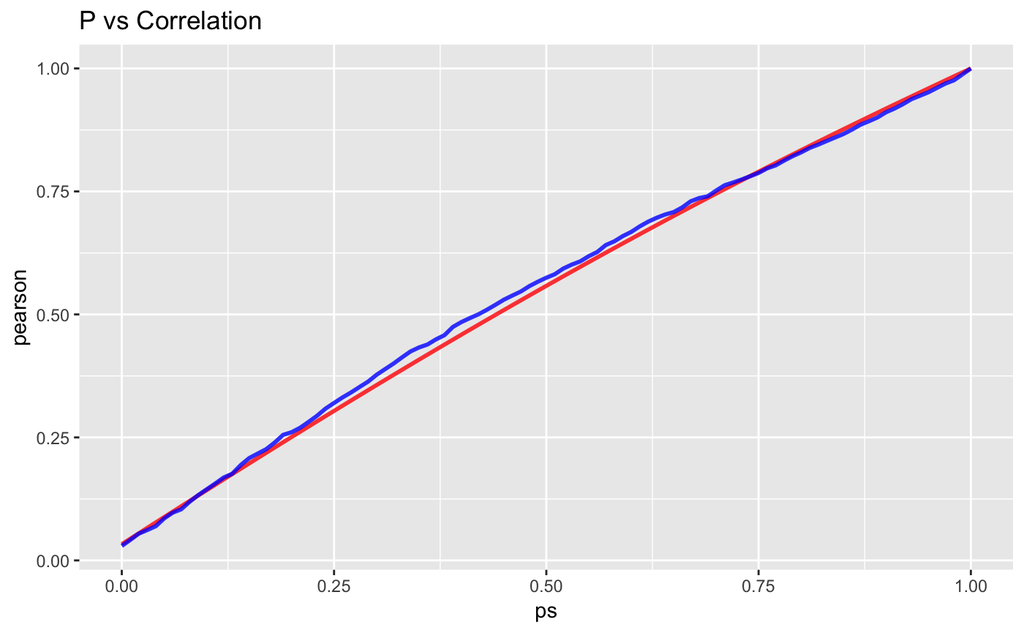

```r
ggplot(data) +
  ggtitle("P vs Correlation") +
  geom_line(aes(x=ps, y=pearson), color='red', size=1, alpha=0.8) +
  geom_line(aes(x=ps, y=spearman), color='blue', size=1, alpha=0.8)
```

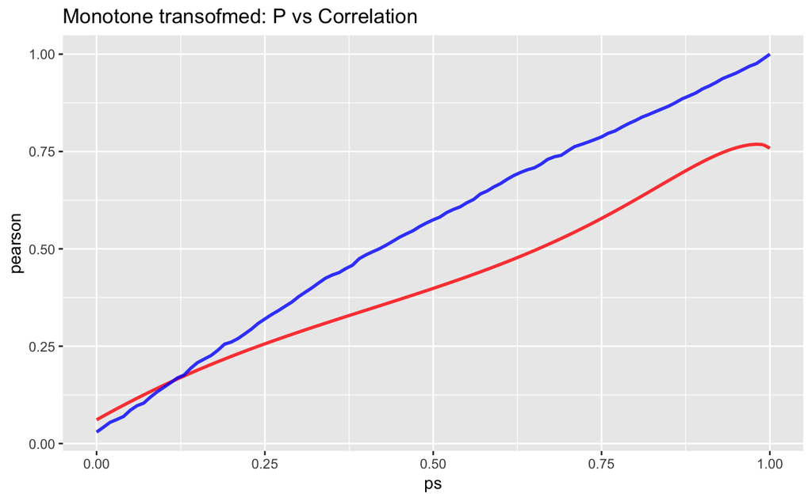

```r
ggplot(data_lt) +
  ggtitle("Monotone transofmed: P vs Correlation") +
  geom_line(aes(x=ps, y=pearson), color='red', size=1, alpha=0.8) +
  geom_line(aes(x=ps, y=spearman), color='blue', size=1, alpha=0.8)
```